# Explicit MPC

Model predictive control (MPC) is not computationally cheap (compared to, say, PID or LQG control) as it requires solving optimization problem – typically a quadratic program (QP) - online. The optimization solver needs to be a part of the controller.

There is an alternative, though, at least in the case of a quadratic cost and a constrained linear system. It is called *explicit MPC*. The computationally heavy optimization is only performed during the design process and the MPC controller is then implemented just as an affine state feedback

$$\boxed{
\bm u_k(\bm x_k) = \mathbf F^i \bm x_k + \mathbf g^i,\; \text{if}\; \bm x_k\in \mathcal R^i,}$$
where $\mathbf F^i$ and $\mathbf g^i$ are the coefficient matrices and vectors that parameterize the affine state feedback controller, and $\mathcal R^i, \; i=1, 2, \ldots, p$ are polyhedral regions, into which the state space $\mathbb R^n$, or more realistically its subset $\mathcal X \subset \mathbb R^n$ over which the control is considered, is partitioned, that is, $\mathcal X = \bigcup_{i=1}^p \mathcal R^i$. The regions $\mathcal R^i$ are polygonal, that is, they can be characterized by a set of linear inequalities:
$$\boxed{
\mathcal R^i = \{\bm x \in \mathbb R^n \;|\; \mathbf H^i \bm x \leq \mathbf k^i \}.}$$

The matrix and vector coefficients $\mathbf F^i, \mathbf g^i, \mathbf H^i, \mathbf k^i$ for $i=1, \ldots, p$ are determined during the offline design process.

What remains to be done online (in real time) is to determine the region $\mathcal R^i$ in which the current state $\bm x_k$ is located. Reducing the computational complexity of this task can be helped by using a clever data structure for the region partitioning. Once the regions is identified, the corresponding affine state feedback law is applied.

## Multiparametric programming

The key technique for explicit MPC is *multi-parametric programming*. Consider the following optimization problem

$$\operatorname*{minimize}_{\bm u\in \mathbb R^m} J(\bm u;\bm x),$$
where $\bm u\in \mathbb R^m$ is an optimization (vector) variable, while $\bm x\in \mathbb R^n$ is a vector of parameters.

**TipUsing a semicolon in function notation**

It is a common notational convention to separate variables and parameters using the semicolon.

For a given parameter $\bm x$, the cost function $J$ is to be minimized. Such minimium (assumming it exists) is denoted as $J^\star$ as usual, but it is still parameterized by $\bm x$

$$J^\star(\bm x) = \inf_{\bm u\in \mathbb R^m} J(\bm u;\bm x).$$

For each value of the parameter $\bm x$, we can find the minimum of $J$ with respect to $\bm u$ by solving the optimization problem from the scratch. Alternatively, we may ask if it is possible to exploit somehow the dependence of the cost function on the parameter in some parameterization of the optimal solution by the same parameter.

The answer is yes! For a scalar parameter, this task is called *parametric programming*, for vector parameters, the name of the problem changes to *multiparametric programming*.

**Example 1 (Parametric programming)** Consider the following cost function $J(u;x)$ of the variable $u\in\mathbb R$, parameterized by $x\in \mathbb R$. The optimization variable $u$ is subject to an inequality constraint, and this constraint is also parameterized by $x$.
$$\begin{aligned}
J(u;x) &= \frac{1}{2} u^2 + 2ux + 2x^2 \\
\text{subject to} &\quad u \leq 1 + x.
\end{aligned}$$

In this simple case we can aim at analytical solution. We proceed in the standard way – we introduce a Lagrange multiplicator $\lambda$ and form the augmented cost function
$$L(u,\lambda; x) = \frac{1}{2} u^2 + 2ux + 2x^2 + \lambda (u-1-x).$$

The necessary conditions of optimality for the inequality-constrained problem come in the form of KKT conditions
$$\begin{aligned}
u + 2x + \lambda &= 0,\\
u - 1 - x &\leq 0,\\
\lambda & \geq 0,\\
\lambda (u - 1 - x) &= 0.
\end{aligned}$$

The last condition – the complementarity condition – gives rise to two scenarios: one corresponding to $\lambda = 0$, and the other corresponding to $u - 1 - x = 0$. We consider them separately below.

After substituting $\lambda = 0$ into the KKT conditions, we get
$$\begin{aligned}
u + 2x &= 0,\\
u - 1 - x & \leq 0.
\end{aligned}$$

From the first equation we get how $u$ depends on $x$, and from the second we obtain a bound on $x$. Finally, we can also substitute the expression for $u$ into the cost function $J$ to get the optimal cost $J^\star$ as a function of $x$. All these are summarized here
$$\begin{aligned}
u &= -2x,\\
x & \geq -\frac{1}{3},\\
J^\star(x) &= 0.
\end{aligned}$$

Now, the other scenario. Upon substituting $u - 1 - x = 0$ into the KKT conditions we get
$$\begin{aligned}
u + 2x + \lambda &= 0,\\
u - 1 - x &= 0,\\
\lambda & \geq 0.
\end{aligned}$$

From the second equation we get the expression for $u$ in terms of $x$, substituting into the first equation and invoking the condition on nonnegativity of $\lambda$ we get the bound on $x$ (not suprisingly it complements the one obtained in the previous scenario). Finally, substituting for $u$ in the cost function $J$ we get a formula for the cost $J^\star$ as a function of $x$

$$\begin{aligned}
u &= 1 + x,\\
\lambda &= -u - 2x \geq 0 \quad \implies \quad x \leq -\frac{1}{3},\\
J^\star(x) &= \frac{9}{2}x^2 + 3x + \frac{1}{2}.
\end{aligned}$$

The two scenarios can now be combined into a single piecewise affine function $u^\star(x)$
$$u^\star(x) = \begin{cases}
1+x & \text{if } x \leq -\frac{1}{3},\\
-2x & \text{if } x > -\frac{1}{3}.
\end{cases}$$

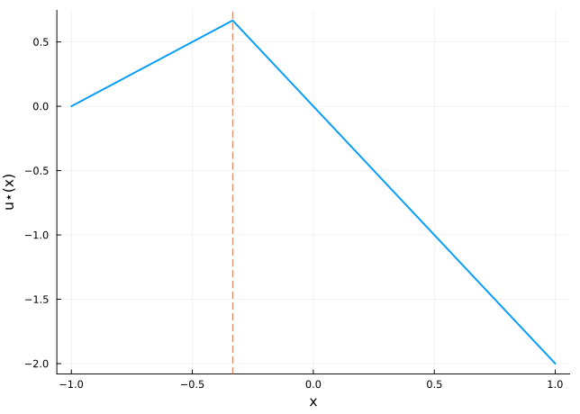

Figure 1: Piecewise affine dependence of the minimizer on the parameter

```julia
x = range(-1, 1, length=100)
u(x) = x <= -1/3 ? 1 + x : -2x
Jstar(x) = x <= -1/3 ? 9/2*x^2 + 3x + 1/2 : 0

using Plots
plot(x, u.(x), label="",lw=2)
vline!([-1/3],line=:dash, label="")
xlabel!("x")
ylabel!("u⋆(x)")
```

and a piecewise quadratic cost function $J^\star(x)$
$$J^\star(x) = \begin{cases}
\frac{9}{2}x^2 + 3x + \frac{1}{2} & \text{if } x \leq -\frac{1}{3},\\
0 & \text{if } x > -\frac{1}{3}.
\end{cases}$$

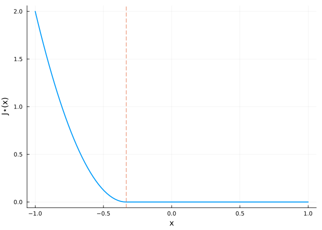

Figure 2: Piecewise quadratic dependence of the optimal cost on the parameter

```julia
plot(x, Jstar.(x), label="",lw=2)
vline!([-1/3],line=:dash, label="")
xlabel!("x")
ylabel!("J⋆(x)")
```

### Software for multiparametric programming

- [MPT3](https://www.mpt3.org/) – a toolbox for Matlab, functionality for explicit MPC.
- [POP](https://parametric.tamu.edu/POP/) - a toolbox for Matlab, interfacing with YALMIP.
- [ParametricDAQP.jl](https://github.com/darnstrom/ParametricDAQP.jl/) – a Julia package for multiparametric quadratic programming.

## Explicit MPC

As we have discussed a few times, the cost of a finite-horizon optimal control problem is a function of the control trajectory $\bm u_0, \bm u_1, \ldots, \bm u_{N-1}$, while the initial state $\bm x_0$ is a parameter (not subject to optimization)

$$J\left(\begin{bmatrix}\bm u_0\\ \bm u_1\\ \vdots \\ \bm u_{N-1}\end{bmatrix}; \bm x_0\right) = \phi(\bm x_N) + \sum_{k=0}^{N-1} L(\bm x_k, \bm u_k).$$

You may now perhaps appreciate our choice of notation in the previous paragraphs in that we used $\bm x$ as the parameter. It fits here perfectly. The state at the beginning of the time horizon over which the optimal control is computed is a parameter, while the optimization is performed over the sequence of controls (control trajectory).

Considering that the cost function is quadratic, and parameterized by a vector, we can apply the multiparametric programming techniquest to find the optimal control law as a function of the state (here playing the role of a vector parameter).

### Software for explicit MPC

#### Matlab

- [Multi-Parametric Toolbox 3 (MPT3)](https://www.mpt3.org/) – Multi-Parametric Toolbox used to be the flagship toolbox for the whole concept of explicit MPC (and related). It was developed in 2000s by [prof. Michal Kvasnica](https://www.uiam.sk/~kvasnica/?show_id=3&lang=sk), then a PhD student at ETH Zurich. The latest version has not been updated since 2019 though.
- [Hybrid Toolbox](https://cse.lab.imtlucca.it/~bemporad/hybrid/toolbox/) – the toolbox has been developed and maintained by [prof. Alberto Bemporad](https://cse.lab.imtlucca.it/~bemporad/), the author of the whole concept of explicit MPC. The toolbox also supports explicit MPC for linear and hybrid systems. It is still maintained (last update in the spring 2025, as of the spring 2026).
- [Model Predictive Control Toolbox for Matlab](https://www.mathworks.com/products/model-predictive-control.html) – the commercial toolbox by The Mathworks also [supports explicit MPC](https://www.mathworks.com/help/mpc/explicit-mpc-design.html).

#### Julia

- LinearMPC.jl – a Julia package for linear MPC, with [support for explicit MPC](https://darnstrom.github.io/LinearMPC.jl/stable/manual/explicit/). It is based on a new solver [ParametricDAQP.jl](https://github.com/darnstrom/ParametricDAQP.jl/) for parametric programming. It also enables export of a C code.

### Examples

```julia
using LinearMPC
mpc,para_range= LinearMPC.mpc_examples("dcmotor")
para_range.xmin[1:2] = -[0.3;2.0]
para_range.xmax[1:2] = [0.3;2.0]
empc = LinearMPC.ExplicitMPC(mpc;range=para_range)
```

```
>> #1|Pending : 0|Finished: 0|
>> #2|Pending : 0|Finished: 1|
>> #3|Pending : 0|Finished: 11|
>> #4|Pending : 0|Finished: 47|
>> #5|Pending : 0|Finished: 69|
>> #6|Pending : 0|Finished: 69|
======= Solution with 69 critical regions =======
```

[output not shown]

We plot the (critical) regions of the state space in Fig. 3.

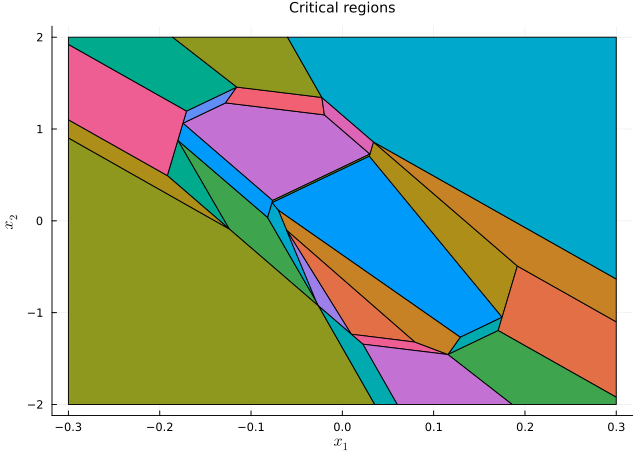

Figure 3: Critical regions of the explicit MPC controller

```julia
using Plots
plot(empc; parameters=[:x1,:x2],r=[0.5,0.0], title="Critical regions")
```

and we also plot the corresponding feedback law in Fig. 4.

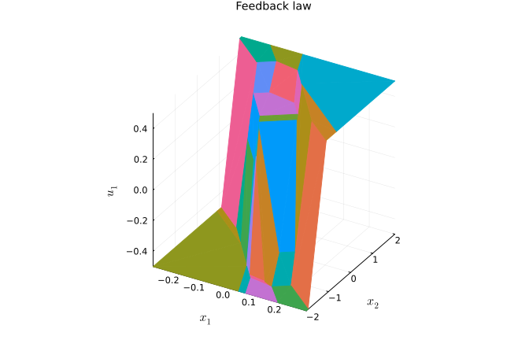

Figure 4: Feedback law of the explicit MPC controller

```julia
plot(empc; parameters=[:x1,:x2], control=:u1, r=[0.5,0.0], title= "Feedback law")
```

The controller is implemented as a tree data structure by

```julia
build_tree!(empc)
```

```
[ Info: Building binary search tree
```

```
Tree depth:       11
# of Nodes:       647
# of Reals:       992
# of Integers:    1294
# of Feedbacks:   35
# of Half-planes: 89
```

We can now compute the control action for a given state by

```julia
compute_control(empc,[0.2, 1.0, 0, 0]; r=[0.5, 0.0])
```

```
1-element Vector{Float64}:
 0.5
```

Back to top